# Cambi bulk RNA-seq

AnnaS

Last edited 30 September 2024

```r
set.seed(1)
```

Goal: To study the mRNA expression between the genotypes

# 1 Experimental set-up and preparing the data

Samples(genotypes):  
- NS1-C2d  
- NS1-TGFb2d  
- NS1-IL1a2d  
- NS1-TplusI2d  
- NS1-C4d  
- NS1-TGFb4d  
- NS1-IL1a4d  
- NS1-TplusI4d  
- NS1-TGFbswap  
- NS1-TGFbwash  
- NS1-IL1aswap  
- NS1-IL1awash  
- NS2-C2d  
- NS2-TGFb2d  
- NS2-IL1a2d  
- NS2-TplusI2d  
- NS2-C4d  
- NS2-TGFb4d  
- NS2-IL1a4d  
- NS2-TplusI4d  
- NS2-TGFbswap  
- NS2-TGFbwash  
- NS2-IL1aswap  
- NS2-IL1awash  
- NS3-C2d  
- NS3-TGFb2d  
- NS3-IL1a2d  
- NS3-TplusI2d  
- NS3-C4d  
- NS3-TGFb4d  
- NS3-IL1a4d  
- NS3-TplusI4d  
- NS3-TGFbswap  
- NS3-TGFbwash  
- NS3-IL1aswap  
- NS3-IL1awash

Load the libraries

```r
library(readr)
library(dplyr)
library(tidyverse)
library(BiocManager)
library(DESeq2)
library(vsn)
library(pheatmap)
library(ComplexHeatmap)
library(ggplot2)
library(org.Mm.eg.db)
library(AnnotationDbi)
library(hexbin)
library(ggrepel)
library(clusterProfiler)
library(edgeR) #pca
library(factoextra) #pca
library(RColorBrewer) #heatmap
library(progeny)


experiment_id <- "Cambi_bulk_RNA-seq"
```

## 1.1 Load the counts dataset from seq2science results directory

```r
#read in counts and filter out low counts
data.counts <- read.table("../GRCm39-counts.tsv", header=TRUE, row.names=1)
data.counts[,c(1,2,3,4,13,14,15,16,25,26,27,28)] <- NULL
colnames(data.counts) <- gsub("4d", "", gsub("TplusI", "mix", gsub("TGFbswap", "TGFb->IL1a", gsub("IL1aswap", "IL1a->TGFb", colnames(data.counts)))))

#reorder the columns so the replicates are next to each other
data.counts.reord <- data.counts[,c(1,9,17,6,14,22,2,10,18,4,12,20,5,13,21,7,15,23,3,11,19,8,16,24)]

#total number of mapped reads in the pool
data.reads.tot <- sum(data.counts.reord)
data.reads.tot
```

```
## [1] 7347398
```

```r
#check the number of mapped reads per sample based on the gene count table
data.reads.sum <-colSums(data.counts.reord)
data.reads.sum
```

```
##          NS1.C          NS2.C          NS3.C   NS1.TGFbwash   NS2.TGFbwash
##         282139         303485         321840         305976         410779
##   NS3.TGFbwash       NS1.TGFb       NS2.TGFb       NS3.TGFb        NS1.mix
##         327576          33657         320212         457788         216081
##        NS2.mix        NS3.mix NS1.TGFb->IL1a NS2.TGFb->IL1a NS3.TGFb->IL1a
##         292549         353979         251053         414297         345061
## NS1.IL1a->TGFb NS2.IL1a->TGFb NS3.IL1a->TGFb       NS1.IL1a       NS2.IL1a
##         287386         297947         321486         294021         317224
##       NS3.IL1a   NS1.IL1awash   NS2.IL1awash   NS3.IL1awash
##         281177         273756         337471         300458
```

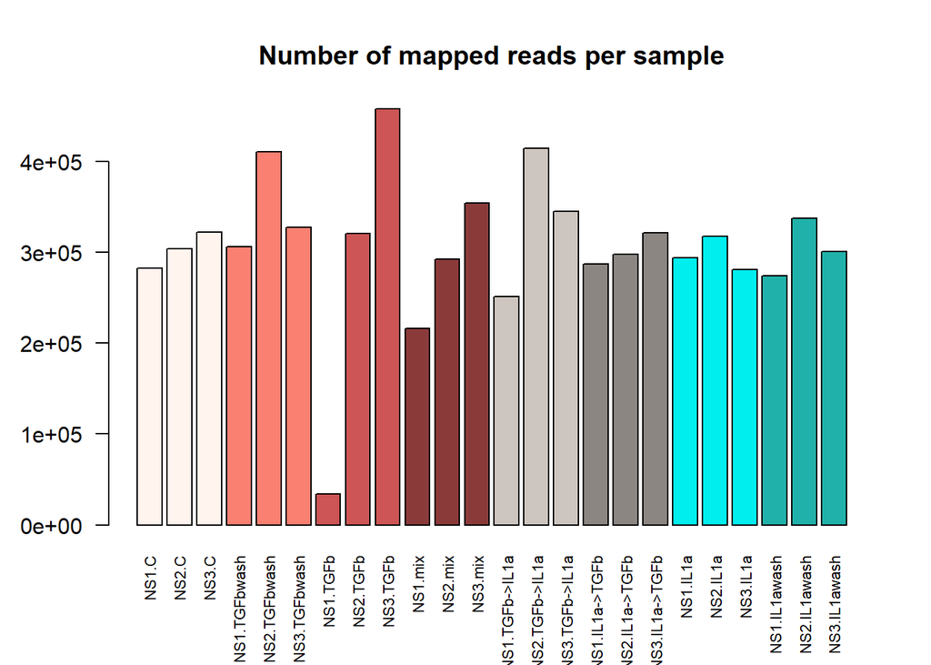

```r
barplot(data.reads.sum, main = "Number of mapped reads per sample", col = c("seashell1", "seashell1", "seashell1", "salmon", "salmon", "salmon", "indianred3", "indianred3", "indianred3", "indianred4", "indianred4", "indianred4", "seashell3", "seashell3", "seashell3", "seashell4", "seashell4", "seashell4", "cyan2", "cyan2", "cyan2", "lightseagreen", "lightseagreen", "lightseagreen", "turquoise4", "turquoise4", "turquoise4"), las=2, cex.names = 0.7)
```

```r
#check the number of detected genes per sample
data.gene.sum <- colSums(data.counts.reord !=0)
data.gene.sum
```

```
##          NS1.C          NS2.C          NS3.C   NS1.TGFbwash   NS2.TGFbwash
##          14773          14603          14685          14463          15524
##   NS3.TGFbwash       NS1.TGFb       NS2.TGFb       NS3.TGFb        NS1.mix
##          14499           7425          14437          16050          13458
##        NS2.mix        NS3.mix NS1.TGFb->IL1a NS2.TGFb->IL1a NS3.TGFb->IL1a
##          14053          14543          13975          15898          14744
## NS1.IL1a->TGFb NS2.IL1a->TGFb NS3.IL1a->TGFb       NS1.IL1a       NS2.IL1a
##          14260          14315          14350          14795          14823
##       NS3.IL1a   NS1.IL1awash   NS2.IL1awash   NS3.IL1awash
##          14121          14224          14779          14736
```

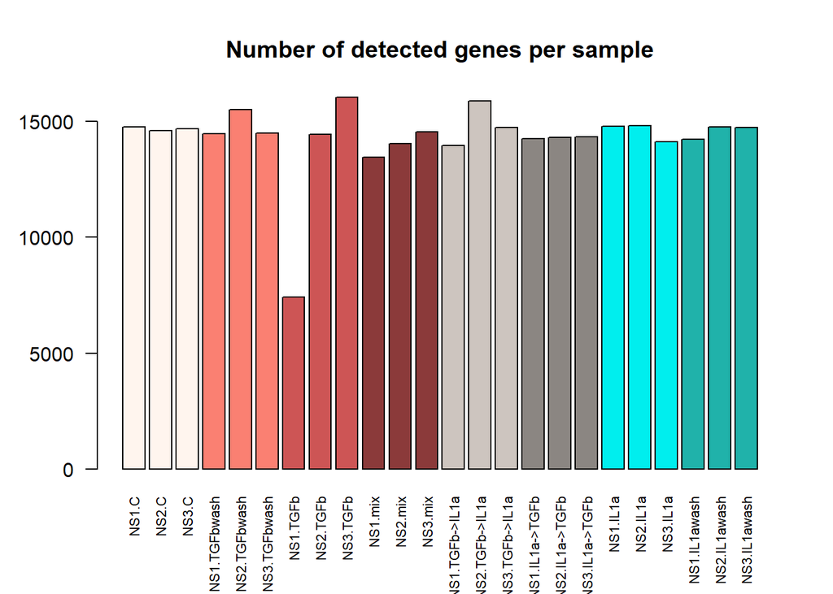

```r
barplot(data.gene.sum, main = "Number of detected genes per sample", col = c("seashell1", "seashell1", "seashell1", "salmon", "salmon", "salmon", "indianred3", "indianred3", "indianred3", "indianred4", "indianred4", "indianred4", "seashell3", "seashell3", "seashell3", "seashell4", "seashell4", "seashell4", "cyan2", "cyan2", "cyan2", "lightseagreen", "lightseagreen", "lightseagreen", "turquoise4", "turquoise4", "turquoise4"), las=2, cex.names = 0.7)
```

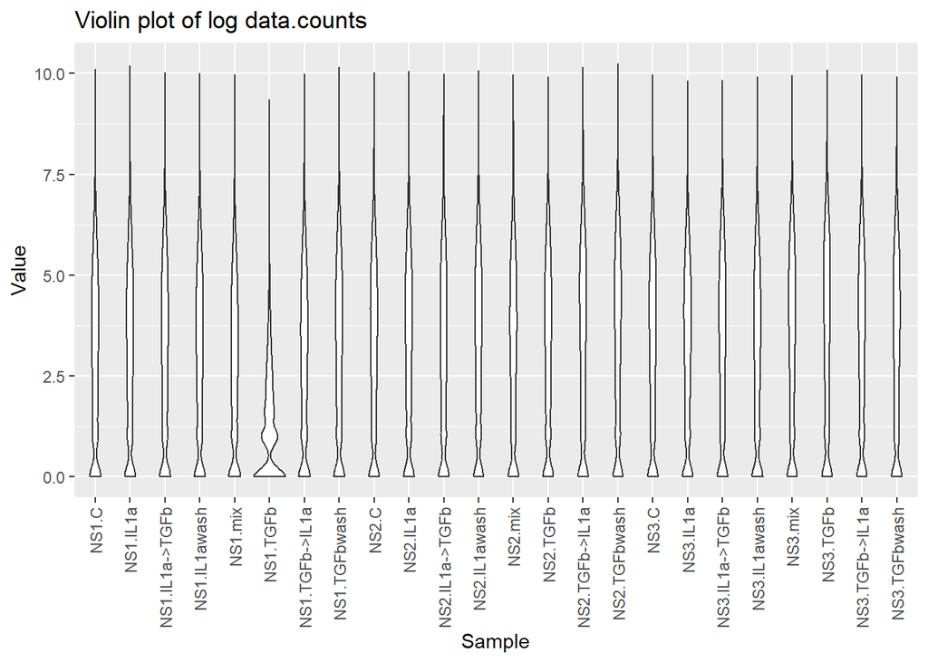

```r
#Violin plot and boxplot of the log data counts

#filter out rows containing only 0
data.wo.0 <- data.counts.reord[rowSums(data.counts.reord != 0) > 0,]
#log transform the data
data.log <- as.data.frame(log2(data.counts.reord))
#gather data in two columns
data.log.gather <- gather(data.log, Sample, Value)


#plot the gather data
##data.log
ggplot(data.log.gather, aes(x=Sample, y=Value)) + geom_violin() + ggtitle("Violin plot of log data.counts") + theme(axis.text.x = element_text(angle = 90, vjust = 0.5, hjust=1))
```

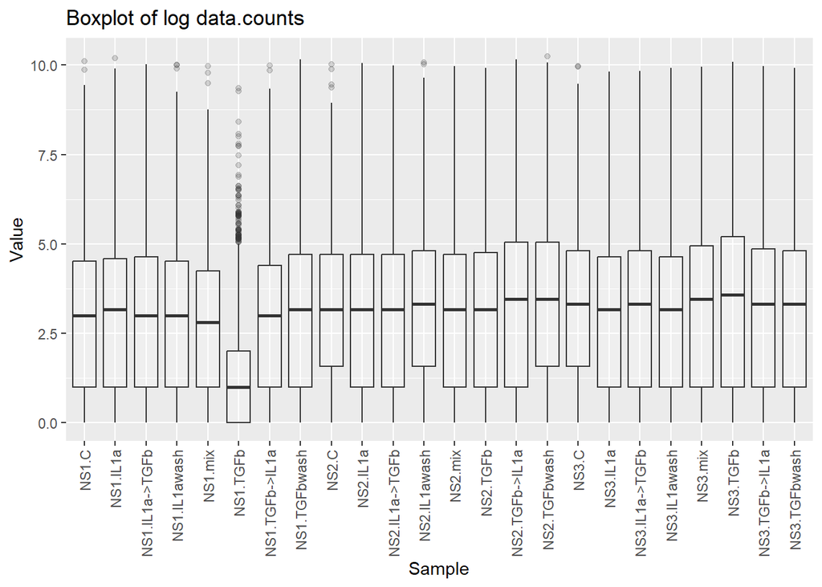

```r
ggplot(data.log.gather, aes(x=Sample, y=Value)) + geom_boxplot(alpha=0.2) + ggtitle("Boxplot of log data.counts") + theme(axis.text.x = element_text(angle = 90, vjust = 0.5, hjust=1))
```

```r
#heatmap
```

## 1.2 Gene annotation

```r
#filter the data, more than 10 reads inmore than 3 columns
data.counts <- data.counts.reord[rowSums(data.counts<10) <3,]

#rename the genes from ENSMUSG00000040952.17 to ENSMUSG00000040952
rownames(data.counts.reord) <- sub("\\..*", "", rownames(data.counts.reord))

#annotate genes in counts, if there is NA gene name, keep the gene symbol
gene_names <- mapIds(org.Mm.eg.db, keys = rownames(data.counts.reord), keytype = "ENSEMBL", column = "SYMBOL")
data.counts.reord$genes <- ifelse(is.na(gene_names), rownames(data.counts.reord), gene_names)

#change the gene column to rownames
data.merge.duplicates <- data.counts.reord %>% group_by(genes) %>% summarise_all(sum)
data.counts.final <- column_to_rownames(data.merge.duplicates, var="genes")
```

# 2 DESeq

## 2.1 Prepare colData for DESeq

```r
#Preparing the metadata table for DESeq2

metadata <- data.frame(sample = colnames(data.counts.final))

metadata$stimulation <- ifelse(grepl("TGFb->IL1a", metadata$sample), "TGFb->IL1a",
                              ifelse(grepl("IL1a->TGFb", metadata$sample), "IL1a->TGFb",
                                     ifelse(grepl("TGFbwash", metadata$sample), "TGFbwash",
                                            ifelse(grepl("IL1awash", metadata$sample), "IL1awash",
                                                   ifelse(grepl("C", metadata$sample), "ctrl",
                                                          ifelse(grepl("mix", metadata$sample), "mix",
                                                                 ifelse(grepl("TGFb", metadata$sample), "TGFb",
                                                                        ifelse(grepl("IL1a", metadata$sample), "IL1a",
                                           "other"))))))))

metadata$batch <- ifelse(grepl("NS1", metadata$sample), "1+2",
                         ifelse(grepl("NS2", metadata$sample), "1+2",
                                ifelse(grepl("NS3", metadata$sample), "3",
                                       "other")))

rownames(metadata) <- metadata$sample
metadata$sample <- NULL
metadata
```

```
##                stimulation batch
## NS1.C                 ctrl   1+2
## NS2.C                 ctrl   1+2
## NS3.C                 ctrl     3
## NS1.TGFbwash      TGFbwash   1+2
## NS2.TGFbwash      TGFbwash   1+2
## NS3.TGFbwash      TGFbwash     3
## NS1.TGFb              TGFb   1+2
## NS2.TGFb              TGFb   1+2
## NS3.TGFb              TGFb     3
## NS1.mix                mix   1+2
## NS2.mix                mix   1+2
## NS3.mix                mix     3
## NS1.TGFb->IL1a  TGFb->IL1a   1+2
## NS2.TGFb->IL1a  TGFb->IL1a   1+2
## NS3.TGFb->IL1a  TGFb->IL1a     3
## NS1.IL1a->TGFb  IL1a->TGFb   1+2
## NS2.IL1a->TGFb  IL1a->TGFb   1+2
## NS3.IL1a->TGFb  IL1a->TGFb     3
## NS1.IL1a              IL1a   1+2
## NS2.IL1a              IL1a   1+2
## NS3.IL1a              IL1a     3
## NS1.IL1awash      IL1awash   1+2
## NS2.IL1awash      IL1awash   1+2
## NS3.IL1awash      IL1awash     3
```